# Interpreting Linear Regression

# Load Data

```r
# load data
cg <- read.csv("data/clark-golder-2006.csv")

# quick look
library(dplyr)
glimpse(cg)
```

```
## Observations: 588
## Variables: 7
## $ country           (fctr) Albania, Albania, Albania, Argentina, Argen...
## $ year              (int) 1992, 1996, 1997, 1946, 1951, 1954, 1958, 19...
## $ average_magnitude (dbl) 1.00, 1.00, 1.00, 10.53, 10.53, 4.56, 8.13, ...
## $ eneg              (dbl) 1.10693, 1.10693, 1.10693, 1.34210, 1.34210,...
## $ enep              (dbl) 2.190, 2.785, 2.870, 5.750, 1.970, 1.930, 2....
## $ enlp              (dbl) 1.95, 1.31, 2.07, 3.74, 1.21, 1.26, 1.72, 2....
## $ type              (fctr) Single-Member District, Single-Member Distr...
```

# Plot Data

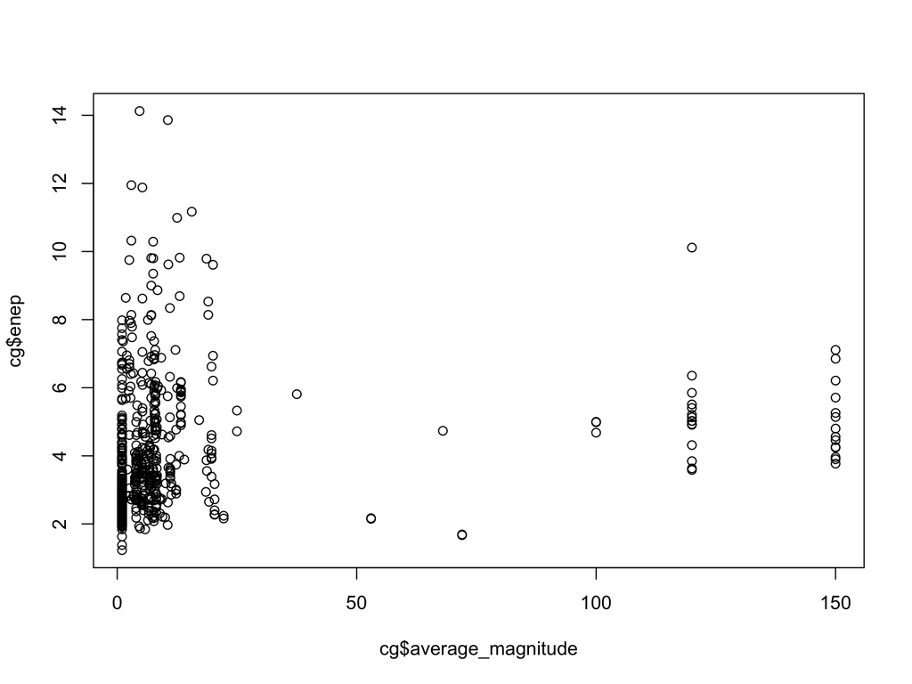

```r
plot(cg$average_magnitude, cg$enep)
```

# Fit Linear Model with Least Squares

```r
m <- lm(enep ~ average_magnitude, data = cg)
coef(m)
```

```
##       (Intercept) average_magnitude
##       3.968080326       0.009803759
```

# Add Line to Plot

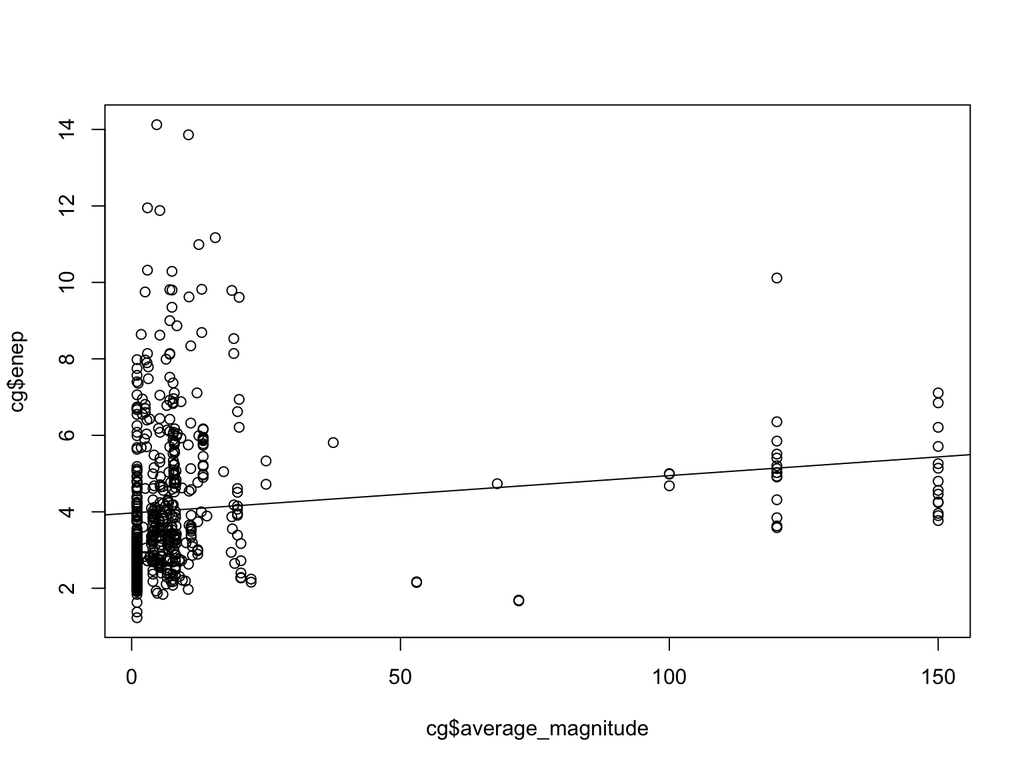

```r
plot(cg$average_magnitude, cg$enep)
abline(m)
```

# Our Model

$y = \alpha + \beta x + \epsilon$

$\text{ENEP} = \alpha + \beta \text{magnitude} + \epsilon$

$\text{ENEP} = 3.97 + 0.01 \text{magnitude} + \epsilon$

$\text{mean}(\text{ENEP} | \text{magnitude}) = 3.97 + 0.01 \text{magnitude}~ \leftarrow$ conditional mean

Assuming this model is correct, what can we say about it? How can we intepret it?

# Question

What is this a line of?

$mean(y)$ versus $mean(y | x)$

# Question

What does our model say about single-member districts?

Model, what do you say about single-member districts?

\begin{align} \text{mean}(\text{ENEP}~|~\text{magnitude}) &= 3.97 + 0.01 \text{magnitude}\\ \text{mean}(\text{ENEP}~|~\text{magnitude} = 1) &= 3.97 + 0.01 \times 1\\ \text{mean}(\text{ENEP}~|~\text{magnitude} = 1) &= 3.97 + 0.01\\ \text{mean}(\text{ENEP}~|~\text{magnitude} = 1) &= 3.98 \end{align}

# Question

What does our model say about ten-member districts?

Model, what do you say about ten-member districts?

\begin{align} \text{mean}(\text{ENEP}~|~\text{magnitude}) &= 3.97 + 0.01 \text{magnitude}\\ \text{mean}(\text{ENEP}~|~\text{magnitude} = 10) &= 3.97 + 0.01 \times 10\\ \text{mean}(\text{ENEP}~|~\text{magnitude} = 10) &= 3.97 + 0.1\\ \text{mean}(\text{ENEP}~|~\text{magnitude} = 10) &= 4.07 \end{align}

# Question

What does our model say about 100-member districts?

Model, what do you say about 100-member districts?

\begin{align} \text{mean}(\text{ENEP}~|~\text{magnitude}) &= 3.97 + 0.01 \text{magnitude}\\ \text{mean}(\text{ENEP}~|~\text{magnitude} = 100) &= 3.97 + 0.01 \times 100\\ \text{mean}(\text{ENEP}~|~\text{magnitude} = 100) &= 3.97 + 1.0\\ \text{mean}(\text{ENEP}~|~\text{magnitude} = 100) &= 4.97 \end{align}

These are called **predicted values**.

# Question

So how can we interpret a linear regression model?

1. We can calculate predicted values.

# Question

But what would happen if we switched from single-member districts to 100-member districts?

\begin{align} \text{mean}(\text{ENEP}~|~\text{magnitude} = 100) - \text{mean}(\text{ENEP}~|~\text{magnitude} = 1) &\\ 4.97 - 3.97 &= 1.00 \end{align}

We’d gain about one party, on average.

# Question

But what would happen if we switched from single-member districts to 10-member districts?

We’d gain about one-tenth of a party, on average.

These are called **first differences**.

# Question

So how can we interpret a linear regression model?

1. We can calculate predicted values.
2. We can caluclate first differences.

# Question

What if we increased magnitude by 1?

In general, we can say that a one unit increase in $x$ leads to a $\beta$ unit increase in the mean of $y$.

# Question

So how can we interpret a linear regression model?

1. We can calculate predicted values.
2. We can caluclate first differences.
3. We can look at the slope.

# Question

Which is more informative?

```r
# correlation
cor(cg$average_magnitude, cg$enep)
```

```
## [1] 0.1497798
```

```r
# linear regression
coef(m)
```

```
##       (Intercept) average_magnitude
##       3.968080326       0.009803759
```

# In R

```r
# predicted values
coef(m)[1] + coef(m)[2]*1
coef(m)[1] + coef(m)[2]*10
coef(m)[1] + coef(m)[2]*100

# first differences
coef(m)[1] + coef(m)[2]*10 - coef(m)[1] + coef(m)[2]*1
coef(m)[1] + coef(m)[2]*100 - coef(m)[1] + coef(m)[2]*1

# alternative way to calculate first differences
coef(m)[2]*10 - coef(m)[2]*1
coef(m)[2]*100 - coef(m)[2]*1

# slope
coef(m)[2]
```